# Optimal Treatment Analysis

## Outcome Variable

**Outcome Variable:** ever_stunted

## Predictor Variables

**Intervention Variable:** month

**Adjustment Set:**

unadjusted

## Stratifying Variables

The analysis was stratified on these variable(s):

- agecat
- studyid
- country

## Data Summary

| agecat | studyid | country | month | ever_stunted | n_cell | n |
| --- | --- | --- | --- | --- | --- | --- |
| 0-24 months (no birth st.) | ki0047075b-MAL-ED | BANGLADESH | 1 | 0 | 9 | 217 |
| 0-24 months (no birth st.) | ki0047075b-MAL-ED | BANGLADESH | 1 | 1 | 9 | 217 |
| 0-24 months (no birth st.) | ki0047075b-MAL-ED | BANGLADESH | 2 | 0 | 7 | 217 |
| 0-24 months (no birth st.) | ki0047075b-MAL-ED | BANGLADESH | 2 | 1 | 11 | 217 |
| 0-24 months (no birth st.) | ki0047075b-MAL-ED | BANGLADESH | 3 | 0 | 8 | 217 |
| 0-24 months (no birth st.) | ki0047075b-MAL-ED | BANGLADESH | 3 | 1 | 12 | 217 |
| 0-24 months (no birth st.) | ki0047075b-MAL-ED | BANGLADESH | 4 | 0 | 12 | 217 |
| 0-24 months (no birth st.) | ki0047075b-MAL-ED | BANGLADESH | 4 | 1 | 10 | 217 |
| 0-24 months (no birth st.) | ki0047075b-MAL-ED | BANGLADESH | 5 | 0 | 5 | 217 |
| 0-24 months (no birth st.) | ki0047075b-MAL-ED | BANGLADESH | 5 | 1 | 12 | 217 |
| 0-24 months (no birth st.) | ki0047075b-MAL-ED | BANGLADESH | 6 | 0 | 3 | 217 |
| 0-24 months (no birth st.) | ki0047075b-MAL-ED | BANGLADESH | 6 | 1 | 2 | 217 |
| 0-24 months (no birth st.) | ki0047075b-MAL-ED | BANGLADESH | 7 | 0 | 9 | 217 |
| 0-24 months (no birth st.) | ki0047075b-MAL-ED | BANGLADESH | 7 | 1 | 8 | 217 |
| 0-24 months (no birth st.) | ki0047075b-MAL-ED | BANGLADESH | 8 | 0 | 10 | 217 |
| 0-24 months (no birth st.) | ki0047075b-MAL-ED | BANGLADESH | 8 | 1 | 10 | 217 |
| 0-24 months (no birth st.) | ki0047075b-MAL-ED | BANGLADESH | 9 | 0 | 9 | 217 |
| 0-24 months (no birth st.) | ki0047075b-MAL-ED | BANGLADESH | 9 | 1 | 11 | 217 |
| 0-24 months (no birth st.) | ki0047075b-MAL-ED | BANGLADESH | 10 | 0 | 14 | 217 |
| 0-24 months (no birth st.) | ki0047075b-MAL-ED | BANGLADESH | 10 | 1 | 6 | 217 |
| 0-24 months (no birth st.) | ki0047075b-MAL-ED | BANGLADESH | 11 | 0 | 7 | 217 |
| 0-24 months (no birth st.) | ki0047075b-MAL-ED | BANGLADESH | 11 | 1 | 8 | 217 |
| 0-24 months (no birth st.) | ki0047075b-MAL-ED | BANGLADESH | 12 | 0 | 11 | 217 |
| 0-24 months (no birth st.) | ki0047075b-MAL-ED | BANGLADESH | 12 | 1 | 14 | 217 |
| 0-24 months (no birth st.) | ki0047075b-MAL-ED | BRAZIL | 1 | 0 | 11 | 208 |
| 0-24 months (no birth st.) | ki0047075b-MAL-ED | BRAZIL | 1 | 1 | 2 | 208 |
| 0-24 months (no birth st.) | ki0047075b-MAL-ED | BRAZIL | 2 | 0 | 18 | 208 |
| 0-24 months (no birth st.) | ki0047075b-MAL-ED | BRAZIL | 2 | 1 | 5 | 208 |
| 0-24 months (no birth st.) | ki0047075b-MAL-ED | BRAZIL | 3 | 0 | 18 | 208 |
| 0-24 months (no birth st.) | ki0047075b-MAL-ED | BRAZIL | 3 | 1 | 2 | 208 |

[output cut: 1962 more lines]

The following strata were considered:

- agecat: 0-24 months (no birth st.), studyid: ki0047075b-MAL-ED, country: BANGLADESH
- agecat: 0-24 months (no birth st.), studyid: ki0047075b-MAL-ED, country: BRAZIL
- agecat: 0-24 months (no birth st.), studyid: ki0047075b-MAL-ED, country: INDIA
- agecat: 0-24 months (no birth st.), studyid: ki0047075b-MAL-ED, country: NEPAL
- agecat: 0-24 months (no birth st.), studyid: ki0047075b-MAL-ED, country: PERU
- agecat: 0-24 months (no birth st.), studyid: ki0047075b-MAL-ED, country: SOUTH AFRICA
- agecat: 0-24 months (no birth st.), studyid: ki0047075b-MAL-ED, country: TANZANIA, UNITED REPUBLIC OF
- agecat: 0-24 months (no birth st.), studyid: ki1000108-CMC-V-BCS-2002, country: INDIA
- agecat: 0-24 months (no birth st.), studyid: ki1000108-IRC, country: INDIA
- agecat: 0-24 months (no birth st.), studyid: ki1000109-EE, country: PAKISTAN
- agecat: 0-24 months (no birth st.), studyid: ki1000109-ResPak, country: PAKISTAN
- agecat: 0-24 months (no birth st.), studyid: ki1000304b-SAS-CompFeed, country: INDIA
- agecat: 0-24 months (no birth st.), studyid: ki1000304b-SAS-FoodSuppl, country: INDIA
- agecat: 0-24 months (no birth st.), studyid: ki1017093-NIH-Birth, country: BANGLADESH
- agecat: 0-24 months (no birth st.), studyid: ki1066203-TanzaniaChild2, country: TANZANIA, UNITED REPUBLIC OF
- agecat: 0-24 months (no birth st.), studyid: ki1112895-Guatemala BSC, country: GUATEMALA
- agecat: 0-24 months (no birth st.), studyid: ki1112895-iLiNS-Zinc, country: BURKINA FASO
- agecat: 0-24 months (no birth st.), studyid: ki1113344-GMS-Nepal, country: NEPAL
- agecat: 0-24 months (no birth st.), studyid: ki1114097-CMIN, country: BANGLADESH
- agecat: 0-24 months (no birth st.), studyid: ki1114097-CMIN, country: BRAZIL
- agecat: 0-24 months (no birth st.), studyid: ki1114097-CMIN, country: GUINEA-BISSAU
- agecat: 0-24 months (no birth st.), studyid: ki1114097-CMIN, country: PERU
- agecat: 0-24 months (no birth st.), studyid: ki1114097-CONTENT, country: PERU
- agecat: 0-24 months (no birth st.), studyid: ki1119695-PROBIT, country: BELARUS
- agecat: 0-24 months (no birth st.), studyid: ki1126311-ZVITAMBO, country: ZIMBABWE
- agecat: 0-24 months (no birth st.), studyid: ki1148112-LCNI-5, country: MALAWI
- agecat: 0-24 months (no birth st.), studyid: kiGH5241-JiVitA-3, country: BANGLADESH
- agecat: 0-24 months (no birth st.), studyid: kiGH5241-JiVitA-4, country: BANGLADESH
- agecat: 0-6 months (no birth st.), studyid: ki0047075b-MAL-ED, country: BANGLADESH
- agecat: 0-6 months (no birth st.), studyid: ki0047075b-MAL-ED, country: BRAZIL
- agecat: 0-6 months (no birth st.), studyid: ki0047075b-MAL-ED, country: INDIA
- agecat: 0-6 months (no birth st.), studyid: ki0047075b-MAL-ED, country: NEPAL
- agecat: 0-6 months (no birth st.), studyid: ki0047075b-MAL-ED, country: PERU
- agecat: 0-6 months (no birth st.), studyid: ki0047075b-MAL-ED, country: SOUTH AFRICA
- agecat: 0-6 months (no birth st.), studyid: ki0047075b-MAL-ED, country: TANZANIA, UNITED REPUBLIC OF
- agecat: 0-6 months (no birth st.), studyid: ki1000108-CMC-V-BCS-2002, country: INDIA
- agecat: 0-6 months (no birth st.), studyid: ki1000108-IRC, country: INDIA
- agecat: 0-6 months (no birth st.), studyid: ki1000109-EE, country: PAKISTAN
- agecat: 0-6 months (no birth st.), studyid: ki1000109-ResPak, country: PAKISTAN
- agecat: 0-6 months (no birth st.), studyid: ki1000304b-SAS-CompFeed, country: INDIA
- agecat: 0-6 months (no birth st.), studyid: ki1000304b-SAS-FoodSuppl, country: INDIA
- agecat: 0-6 months (no birth st.), studyid: ki1017093-NIH-Birth, country: BANGLADESH
- agecat: 0-6 months (no birth st.), studyid: ki1066203-TanzaniaChild2, country: TANZANIA, UNITED REPUBLIC OF
- agecat: 0-6 months (no birth st.), studyid: ki1112895-Guatemala BSC, country: GUATEMALA
- agecat: 0-6 months (no birth st.), studyid: ki1113344-GMS-Nepal, country: NEPAL
- agecat: 0-6 months (no birth st.), studyid: ki1114097-CMIN, country: BANGLADESH
- agecat: 0-6 months (no birth st.), studyid: ki1114097-CMIN, country: BRAZIL
- agecat: 0-6 months (no birth st.), studyid: ki1114097-CMIN, country: GUINEA-BISSAU
- agecat: 0-6 months (no birth st.), studyid: ki1114097-CMIN, country: PERU
- agecat: 0-6 months (no birth st.), studyid: ki1114097-CONTENT, country: PERU
- agecat: 0-6 months (no birth st.), studyid: ki1119695-PROBIT, country: BELARUS
- agecat: 0-6 months (no birth st.), studyid: ki1126311-ZVITAMBO, country: ZIMBABWE
- agecat: 0-6 months (no birth st.), studyid: ki1148112-LCNI-5, country: MALAWI
- agecat: 0-6 months (no birth st.), studyid: kiGH5241-JiVitA-3, country: BANGLADESH
- agecat: 0-6 months (no birth st.), studyid: kiGH5241-JiVitA-4, country: BANGLADESH
- agecat: 6-24 months, studyid: ki0047075b-MAL-ED, country: BANGLADESH
- agecat: 6-24 months, studyid: ki0047075b-MAL-ED, country: BRAZIL
- agecat: 6-24 months, studyid: ki0047075b-MAL-ED, country: INDIA
- agecat: 6-24 months, studyid: ki0047075b-MAL-ED, country: NEPAL
- agecat: 6-24 months, studyid: ki0047075b-MAL-ED, country: PERU
- agecat: 6-24 months, studyid: ki0047075b-MAL-ED, country: SOUTH AFRICA
- agecat: 6-24 months, studyid: ki0047075b-MAL-ED, country: TANZANIA, UNITED REPUBLIC OF
- agecat: 6-24 months, studyid: ki1000108-CMC-V-BCS-2002, country: INDIA
- agecat: 6-24 months, studyid: ki1000108-IRC, country: INDIA
- agecat: 6-24 months, studyid: ki1000109-EE, country: PAKISTAN
- agecat: 6-24 months, studyid: ki1000109-ResPak, country: PAKISTAN
- agecat: 6-24 months, studyid: ki1000304b-SAS-CompFeed, country: INDIA
- agecat: 6-24 months, studyid: ki1000304b-SAS-FoodSuppl, country: INDIA
- agecat: 6-24 months, studyid: ki1017093-NIH-Birth, country: BANGLADESH
- agecat: 6-24 months, studyid: ki1066203-TanzaniaChild2, country: TANZANIA, UNITED REPUBLIC OF
- agecat: 6-24 months, studyid: ki1112895-Guatemala BSC, country: GUATEMALA
- agecat: 6-24 months, studyid: ki1112895-iLiNS-Zinc, country: BURKINA FASO
- agecat: 6-24 months, studyid: ki1113344-GMS-Nepal, country: NEPAL
- agecat: 6-24 months, studyid: ki1114097-CMIN, country: BANGLADESH
- agecat: 6-24 months, studyid: ki1114097-CMIN, country: BRAZIL
- agecat: 6-24 months, studyid: ki1114097-CMIN, country: GUINEA-BISSAU
- agecat: 6-24 months, studyid: ki1114097-CMIN, country: PERU
- agecat: 6-24 months, studyid: ki1114097-CONTENT, country: PERU
- agecat: 6-24 months, studyid: ki1119695-PROBIT, country: BELARUS
- agecat: 6-24 months, studyid: ki1126311-ZVITAMBO, country: ZIMBABWE
- agecat: 6-24 months, studyid: ki1148112-LCNI-5, country: MALAWI
- agecat: 6-24 months, studyid: kiGH5241-JiVitA-3, country: BANGLADESH
- agecat: 6-24 months, studyid: kiGH5241-JiVitA-4, country: BANGLADESH

### Dropped Strata

Some strata were dropped due to rare outcomes:

- agecat: 0-24 months (no birth st.), studyid: ki0047075b-MAL-ED, country: BANGLADESH
- agecat: 0-24 months (no birth st.), studyid: ki0047075b-MAL-ED, country: BRAZIL
- agecat: 0-24 months (no birth st.), studyid: ki0047075b-MAL-ED, country: INDIA
- agecat: 0-24 months (no birth st.), studyid: ki0047075b-MAL-ED, country: NEPAL
- agecat: 0-24 months (no birth st.), studyid: ki0047075b-MAL-ED, country: SOUTH AFRICA
- agecat: 0-24 months (no birth st.), studyid: ki0047075b-MAL-ED, country: TANZANIA, UNITED REPUBLIC OF
- agecat: 0-24 months (no birth st.), studyid: ki1000108-CMC-V-BCS-2002, country: INDIA
- agecat: 0-24 months (no birth st.), studyid: ki1000108-IRC, country: INDIA
- agecat: 0-24 months (no birth st.), studyid: ki1000109-EE, country: PAKISTAN
- agecat: 0-24 months (no birth st.), studyid: ki1000109-ResPak, country: PAKISTAN
- agecat: 0-24 months (no birth st.), studyid: ki1000304b-SAS-FoodSuppl, country: INDIA
- agecat: 0-24 months (no birth st.), studyid: ki1112895-Guatemala BSC, country: GUATEMALA
- agecat: 0-24 months (no birth st.), studyid: ki1113344-GMS-Nepal, country: NEPAL
- agecat: 0-24 months (no birth st.), studyid: ki1114097-CMIN, country: BANGLADESH
- agecat: 0-24 months (no birth st.), studyid: ki1114097-CMIN, country: BRAZIL
- agecat: 0-24 months (no birth st.), studyid: ki1114097-CONTENT, country: PERU
- agecat: 0-6 months (no birth st.), studyid: ki0047075b-MAL-ED, country: BANGLADESH
- agecat: 0-6 months (no birth st.), studyid: ki0047075b-MAL-ED, country: BRAZIL
- agecat: 0-6 months (no birth st.), studyid: ki0047075b-MAL-ED, country: INDIA
- agecat: 0-6 months (no birth st.), studyid: ki0047075b-MAL-ED, country: NEPAL
- agecat: 0-6 months (no birth st.), studyid: ki0047075b-MAL-ED, country: PERU
- agecat: 0-6 months (no birth st.), studyid: ki0047075b-MAL-ED, country: SOUTH AFRICA
- agecat: 0-6 months (no birth st.), studyid: ki0047075b-MAL-ED, country: TANZANIA, UNITED REPUBLIC OF
- agecat: 0-6 months (no birth st.), studyid: ki1000108-CMC-V-BCS-2002, country: INDIA
- agecat: 0-6 months (no birth st.), studyid: ki1000109-EE, country: PAKISTAN
- agecat: 0-6 months (no birth st.), studyid: ki1000109-ResPak, country: PAKISTAN
- agecat: 0-6 months (no birth st.), studyid: ki1000304b-SAS-FoodSuppl, country: INDIA
- agecat: 0-6 months (no birth st.), studyid: ki1112895-Guatemala BSC, country: GUATEMALA
- agecat: 0-6 months (no birth st.), studyid: ki1113344-GMS-Nepal, country: NEPAL
- agecat: 0-6 months (no birth st.), studyid: ki1114097-CMIN, country: BANGLADESH
- agecat: 0-6 months (no birth st.), studyid: ki1114097-CMIN, country: BRAZIL
- agecat: 0-6 months (no birth st.), studyid: ki1114097-CMIN, country: GUINEA-BISSAU
- agecat: 0-6 months (no birth st.), studyid: ki1114097-CMIN, country: PERU
- agecat: 0-6 months (no birth st.), studyid: ki1114097-CONTENT, country: PERU
- agecat: 0-6 months (no birth st.), studyid: ki1148112-LCNI-5, country: MALAWI
- agecat: 0-6 months (no birth st.), studyid: kiGH5241-JiVitA-4, country: BANGLADESH
- agecat: 6-24 months, studyid: ki0047075b-MAL-ED, country: BANGLADESH
- agecat: 6-24 months, studyid: ki0047075b-MAL-ED, country: BRAZIL
- agecat: 6-24 months, studyid: ki0047075b-MAL-ED, country: INDIA
- agecat: 6-24 months, studyid: ki0047075b-MAL-ED, country: NEPAL
- agecat: 6-24 months, studyid: ki0047075b-MAL-ED, country: PERU
- agecat: 6-24 months, studyid: ki0047075b-MAL-ED, country: SOUTH AFRICA
- agecat: 6-24 months, studyid: ki0047075b-MAL-ED, country: TANZANIA, UNITED REPUBLIC OF
- agecat: 6-24 months, studyid: ki1000108-CMC-V-BCS-2002, country: INDIA
- agecat: 6-24 months, studyid: ki1000108-IRC, country: INDIA
- agecat: 6-24 months, studyid: ki1000109-EE, country: PAKISTAN
- agecat: 6-24 months, studyid: ki1000109-ResPak, country: PAKISTAN
- agecat: 6-24 months, studyid: ki1000304b-SAS-FoodSuppl, country: INDIA
- agecat: 6-24 months, studyid: ki1112895-Guatemala BSC, country: GUATEMALA
- agecat: 6-24 months, studyid: ki1113344-GMS-Nepal, country: NEPAL
- agecat: 6-24 months, studyid: ki1114097-CMIN, country: BANGLADESH
- agecat: 6-24 months, studyid: ki1114097-CMIN, country: BRAZIL
- agecat: 6-24 months, studyid: ki1114097-CONTENT, country: PERU

## Methods Detail

We’re interested in the causal parameters $E[Y_a]$ for all values of $a \in \mathcal{A}$. These parameters represent the mean outcome if, possibly contrary to fact, we intervened to set all units to have $A=a$. Under the randomization and positivity assumptions, these are identified by the statistical parameters $\psi_a=E_W[E_{Y|A,W}(Y|A=a,W)]$. In addition, we’re interested in the mean of $Y$, $E[Y]$ under no intervention (the observed mean). We will estimate these parameters by using SuperLearner to fit the relevant likelihood factors – $E_{Y|A,W}(Y|A=a,W)$ and $p(A=a|W)$, and then updating our likelihood fit using a joint TMLE.

For unadjusted analyses ($W=\{\}$), initial likelihoods were estimated using Lrnr_glm to estimate the simple $E(Y|A)$ and Lrnr_mean to estimate $p(A)$. For adjusted analyses, a small library containing Lrnr_glmnet, Lrnr_xgboost, and Lrnr_mean was used.

Having estimated these parameters, we will then use the delta method to estimate relative risks and attributable risks relative to a prespecified baseline level of $A$.

# Results Detail

## Results Plots

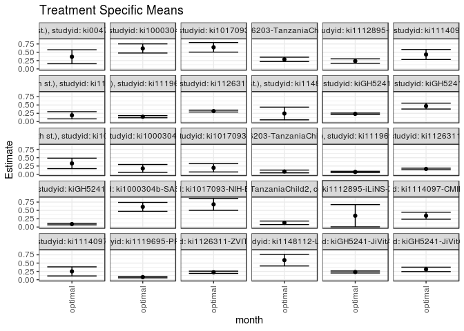

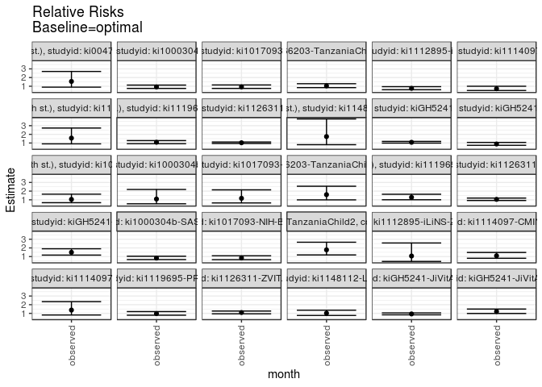

## Results Table

### Parameter: TSM

| agecat | studyid | country | intervention_level | baseline_level | estimate | ci_lower | ci_upper |
| --- | --- | --- | --- | --- | --- | --- | --- |
| 0-24 months (no birth st.) | ki0047075b-MAL-ED | PERU | optimal | NA | 0.3654762 | 0.1555046 | 0.5754479 |
| 0-24 months (no birth st.) | ki1000304b-SAS-CompFeed | INDIA | optimal | NA | 0.6148143 | 0.4776169 | 0.7520116 |
| 0-24 months (no birth st.) | ki1017093-NIH-Birth | BANGLADESH | optimal | NA | 0.6489424 | 0.5046553 | 0.7932296 |
| 0-24 months (no birth st.) | ki1066203-TanzaniaChild2 | TANZANIA, UNITED REPUBLIC OF | optimal | NA | 0.2871958 | 0.2223132 | 0.3520784 |
| 0-24 months (no birth st.) | ki1112895-iLiNS-Zinc | BURKINA FASO | optimal | NA | 0.2356351 | 0.1689201 | 0.3023501 |
| 0-24 months (no birth st.) | ki1114097-CMIN | GUINEA-BISSAU | optimal | NA | 0.4328104 | 0.2821374 | 0.5834835 |
| 0-24 months (no birth st.) | ki1114097-CMIN | PERU | optimal | NA | 0.1899153 | 0.0821592 | 0.2976713 |
| 0-24 months (no birth st.) | ki1119695-PROBIT | BELARUS | optimal | NA | 0.1472722 | 0.1160138 | 0.1785306 |
| 0-24 months (no birth st.) | ki1126311-ZVITAMBO | ZIMBABWE | optimal | NA | 0.3158206 | 0.2886175 | 0.3430236 |
| 0-24 months (no birth st.) | ki1148112-LCNI-5 | MALAWI | optimal | NA | 0.2440617 | 0.0530541 | 0.4350694 |
| 0-24 months (no birth st.) | kiGH5241-JiVitA-3 | BANGLADESH | optimal | NA | 0.2340255 | 0.2116629 | 0.2563881 |
| 0-24 months (no birth st.) | kiGH5241-JiVitA-4 | BANGLADESH | optimal | NA | 0.4664294 | 0.3779261 | 0.5549326 |
| 0-6 months (no birth st.) | ki1000108-IRC | INDIA | optimal | NA | 0.3280861 | 0.1711432 | 0.4850290 |
| 0-6 months (no birth st.) | ki1000304b-SAS-CompFeed | INDIA | optimal | NA | 0.1769937 | 0.0585196 | 0.2954678 |
| 0-6 months (no birth st.) | ki1017093-NIH-Birth | BANGLADESH | optimal | NA | 0.1950913 | 0.0705574 | 0.3196252 |
| 0-6 months (no birth st.) | ki1066203-TanzaniaChild2 | TANZANIA, UNITED REPUBLIC OF | optimal | NA | 0.0858874 | 0.0440124 | 0.1277624 |
| 0-6 months (no birth st.) | ki1119695-PROBIT | BELARUS | optimal | NA | 0.0711717 | 0.0508466 | 0.0914969 |
| 0-6 months (no birth st.) | ki1126311-ZVITAMBO | ZIMBABWE | optimal | NA | 0.1622459 | 0.1399434 | 0.1845484 |
| 0-6 months (no birth st.) | kiGH5241-JiVitA-3 | BANGLADESH | optimal | NA | 0.0878676 | 0.0662001 | 0.1095352 |
| 6-24 months | ki1000304b-SAS-CompFeed | INDIA | optimal | NA | 0.6061265 | 0.4719180 | 0.7403349 |
| 6-24 months | ki1017093-NIH-Birth | BANGLADESH | optimal | NA | 0.6811087 | 0.5009018 | 0.8613155 |
| 6-24 months | ki1066203-TanzaniaChild2 | TANZANIA, UNITED REPUBLIC OF | optimal | NA | 0.1270645 | 0.0744966 | 0.1796324 |
| 6-24 months | ki1112895-iLiNS-Zinc | BURKINA FASO | optimal | NA | 0.3395674 | 0.0050874 | 0.6740473 |
| 6-24 months | ki1114097-CMIN | GUINEA-BISSAU | optimal | NA | 0.3405587 | 0.2351208 | 0.4459965 |
| 6-24 months | ki1114097-CMIN | PERU | optimal | NA | 0.2499580 | 0.1135081 | 0.3864080 |
| 6-24 months | ki1119695-PROBIT | BELARUS | optimal | NA | 0.0787967 | 0.0566865 | 0.1009070 |
| 6-24 months | ki1126311-ZVITAMBO | ZIMBABWE | optimal | NA | 0.2243028 | 0.1904307 | 0.2581748 |
| 6-24 months | ki1148112-LCNI-5 | MALAWI | optimal | NA | 0.5889915 | 0.4133531 | 0.7646299 |
| 6-24 months | kiGH5241-JiVitA-3 | BANGLADESH | optimal | NA | 0.2323445 | 0.2024400 | 0.2622491 |
| 6-24 months | kiGH5241-JiVitA-4 | BANGLADESH | optimal | NA | 0.3105803 | 0.2443270 | 0.3768336 |

### Parameter: E(Y)

| agecat | studyid | country | intervention_level | baseline_level | estimate | ci_lower | ci_upper |
| --- | --- | --- | --- | --- | --- | --- | --- |
| 0-24 months (no birth st.) | ki0047075b-MAL-ED | PERU | observed | NA | 0.5676692 | 0.5080232 | 0.6273151 |
| 0-24 months (no birth st.) | ki1000304b-SAS-CompFeed | INDIA | observed | NA | 0.5660550 | 0.5086421 | 0.6234680 |
| 0-24 months (no birth st.) | ki1017093-NIH-Birth | BANGLADESH | observed | NA | 0.6018868 | 0.5601729 | 0.6436007 |
| 0-24 months (no birth st.) | ki1066203-TanzaniaChild2 | TANZANIA, UNITED REPUBLIC OF | observed | NA | 0.2988814 | 0.2798990 | 0.3178639 |
| 0-24 months (no birth st.) | ki1112895-iLiNS-Zinc | BURKINA FASO | observed | NA | 0.1780497 | 0.1518612 | 0.2042383 |
| 0-24 months (no birth st.) | ki1114097-CMIN | GUINEA-BISSAU | observed | NA | 0.3084337 | 0.2827691 | 0.3340984 |
| 0-24 months (no birth st.) | ki1114097-CMIN | PERU | observed | NA | 0.2976339 | 0.2659904 | 0.3292773 |
| 0-24 months (no birth st.) | ki1119695-PROBIT | BELARUS | observed | NA | 0.1597778 | 0.1408215 | 0.1787342 |
| 0-24 months (no birth st.) | ki1126311-ZVITAMBO | ZIMBABWE | observed | NA | 0.3252945 | 0.3171024 | 0.3334866 |
| 0-24 months (no birth st.) | ki1148112-LCNI-5 | MALAWI | observed | NA | 0.4256121 | 0.3835181 | 0.4677060 |
| 0-24 months (no birth st.) | kiGH5241-JiVitA-3 | BANGLADESH | observed | NA | 0.2535059 | 0.2457125 | 0.2612993 |
| 0-24 months (no birth st.) | kiGH5241-JiVitA-4 | BANGLADESH | observed | NA | 0.4135358 | 0.3953404 | 0.4317312 |
| 0-6 months (no birth st.) | ki1000108-IRC | INDIA | observed | NA | 0.3444444 | 0.2952897 | 0.3935992 |
| 0-6 months (no birth st.) | ki1000304b-SAS-CompFeed | INDIA | observed | NA | 0.1928375 | 0.1691727 | 0.2165022 |
| 0-6 months (no birth st.) | ki1017093-NIH-Birth | BANGLADESH | observed | NA | 0.2283019 | 0.1925336 | 0.2640702 |
| 0-6 months (no birth st.) | ki1066203-TanzaniaChild2 | TANZANIA, UNITED REPUBLIC OF | observed | NA | 0.1369128 | 0.1226581 | 0.1511674 |
| 0-6 months (no birth st.) | ki1119695-PROBIT | BELARUS | observed | NA | 0.0912784 | 0.0781588 | 0.1043979 |
| 0-6 months (no birth st.) | ki1126311-ZVITAMBO | ZIMBABWE | observed | NA | 0.1706248 | 0.1640425 | 0.1772071 |
| 0-6 months (no birth st.) | kiGH5241-JiVitA-3 | BANGLADESH | observed | NA | 0.1311262 | 0.1254945 | 0.1367579 |
| 6-24 months | ki1000304b-SAS-CompFeed | INDIA | observed | NA | 0.5030750 | 0.4588491 | 0.5473009 |
| 6-24 months | ki1017093-NIH-Birth | BANGLADESH | observed | NA | 0.5739130 | 0.5216565 | 0.6261696 |
| 6-24 months | ki1066203-TanzaniaChild2 | TANZANIA, UNITED REPUBLIC OF | observed | NA | 0.2259675 | 0.2054816 | 0.2464534 |
| 6-24 months | ki1112895-iLiNS-Zinc | BURKINA FASO | observed | NA | 0.3623277 | 0.3130786 | 0.4115769 |
| 6-24 months | ki1114097-CMIN | GUINEA-BISSAU | observed | NA | 0.3714710 | 0.3456477 | 0.3972943 |
| 6-24 months | ki1114097-CMIN | PERU | observed | NA | 0.3450439 | 0.3120195 | 0.3780683 |
| 6-24 months | ki1119695-PROBIT | BELARUS | observed | NA | 0.0768510 | 0.0628857 | 0.0908164 |
| 6-24 months | ki1126311-ZVITAMBO | ZIMBABWE | observed | NA | 0.2458438 | 0.2363722 | 0.2553155 |
| 6-24 months | ki1148112-LCNI-5 | MALAWI | observed | NA | 0.6000000 | 0.5644377 | 0.6355623 |
| 6-24 months | kiGH5241-JiVitA-3 | BANGLADESH | observed | NA | 0.2173665 | 0.2079947 | 0.2267384 |
| 6-24 months | kiGH5241-JiVitA-4 | BANGLADESH | observed | NA | 0.3779118 | 0.3593176 | 0.3965059 |

### Parameter: RR

| agecat | studyid | country | intervention_level | baseline_level | estimate | ci_lower | ci_upper |
| --- | --- | --- | --- | --- | --- | --- | --- |
| 0-24 months (no birth st.) | ki0047075b-MAL-ED | PERU | observed | optimal | 1.5532314 | 0.8925023 | 2.7031052 |
| 0-24 months (no birth st.) | ki1000304b-SAS-CompFeed | INDIA | observed | optimal | 0.9206927 | 0.7485396 | 1.1324385 |
| 0-24 months (no birth st.) | ki1017093-NIH-Birth | BANGLADESH | observed | optimal | 0.9274888 | 0.7489312 | 1.1486173 |
| 0-24 months (no birth st.) | ki1066203-TanzaniaChild2 | TANZANIA, UNITED REPUBLIC OF | observed | optimal | 1.0406887 | 0.8388843 | 1.2910398 |
| 0-24 months (no birth st.) | ki1112895-iLiNS-Zinc | BURKINA FASO | observed | optimal | 0.7556164 | 0.6020741 | 0.9483155 |
| 0-24 months (no birth st.) | ki1114097-CMIN | GUINEA-BISSAU | observed | optimal | 0.7126301 | 0.5078653 | 0.9999534 |
| 0-24 months (no birth st.) | ki1114097-CMIN | PERU | observed | optimal | 1.5671930 | 0.9007726 | 2.7266526 |
| 0-24 months (no birth st.) | ki1119695-PROBIT | BELARUS | observed | optimal | 1.0849148 | 0.9216347 | 1.2771222 |
| 0-24 months (no birth st.) | ki1126311-ZVITAMBO | ZIMBABWE | observed | optimal | 1.0299978 | 0.9485404 | 1.1184505 |
| 0-24 months (no birth st.) | ki1148112-LCNI-5 | MALAWI | observed | optimal | 1.7438706 | 0.8059147 | 3.7734573 |
| 0-24 months (no birth st.) | kiGH5241-JiVitA-3 | BANGLADESH | observed | optimal | 1.0832405 | 0.9903067 | 1.1848954 |
| 0-24 months (no birth st.) | kiGH5241-JiVitA-4 | BANGLADESH | observed | optimal | 0.8865989 | 0.7340951 | 1.0707844 |
| 0-6 months (no birth st.) | ki1000108-IRC | INDIA | observed | optimal | 1.0498600 | 0.6678540 | 1.6503697 |
| 0-6 months (no birth st.) | ki1000304b-SAS-CompFeed | INDIA | observed | optimal | 1.0895160 | 0.5408153 | 2.1949180 |
| 0-6 months (no birth st.) | ki1017093-NIH-Birth | BANGLADESH | observed | optimal | 1.1702311 | 0.6380381 | 2.1463308 |
| 0-6 months (no birth st.) | ki1066203-TanzaniaChild2 | TANZANIA, UNITED REPUBLIC OF | observed | optimal | 1.5940953 | 0.9915466 | 2.5628043 |
| 0-6 months (no birth st.) | ki1119695-PROBIT | BELARUS | observed | optimal | 1.2825088 | 1.0037428 | 1.6386956 |
| 0-6 months (no birth st.) | ki1126311-ZVITAMBO | ZIMBABWE | observed | optimal | 1.0516430 | 0.9217216 | 1.1998774 |
| 0-6 months (no birth st.) | kiGH5241-JiVitA-3 | BANGLADESH | observed | optimal | 1.4923149 | 1.1722256 | 1.8998082 |
| 6-24 months | ki1000304b-SAS-CompFeed | INDIA | observed | optimal | 0.8299836 | 0.6619977 | 1.0405969 |
| 6-24 months | ki1017093-NIH-Birth | BANGLADESH | observed | optimal | 0.8426160 | 0.6484007 | 1.0950045 |
| 6-24 months | ki1066203-TanzaniaChild2 | TANZANIA, UNITED REPUBLIC OF | observed | optimal | 1.7783685 | 1.1910611 | 2.6552749 |
| 6-24 months | ki1112895-iLiNS-Zinc | BURKINA FASO | observed | optimal | 1.0670275 | 0.4429999 | 2.5700856 |
| 6-24 months | ki1114097-CMIN | GUINEA-BISSAU | observed | optimal | 1.0907695 | 0.8068470 | 1.4746018 |
| 6-24 months | ki1114097-CMIN | PERU | observed | optimal | 1.3804074 | 0.8102814 | 2.3516826 |
| 6-24 months | ki1119695-PROBIT | BELARUS | observed | optimal | 0.9753078 | 0.7895416 | 1.2047817 |
| 6-24 months | ki1126311-ZVITAMBO | ZIMBABWE | observed | optimal | 1.0960356 | 0.9475998 | 1.2677230 |
| 6-24 months | ki1148112-LCNI-5 | MALAWI | observed | optimal | 1.0186904 | 0.7616343 | 1.3625044 |
| 6-24 months | kiGH5241-JiVitA-3 | BANGLADESH | observed | optimal | 0.9355353 | 0.8299112 | 1.0546024 |
| 6-24 months | kiGH5241-JiVitA-4 | BANGLADESH | observed | optimal | 1.2167924 | 0.9894241 | 1.4964096 |

### Parameter: PAR

| agecat | studyid | country | intervention_level | baseline_level | estimate | ci_lower | ci_upper |
| --- | --- | --- | --- | --- | --- | --- | --- |
| 0-24 months (no birth st.) | ki0047075b-MAL-ED | PERU | optimal | NA | 0.2021929 | 0.0007814 | 0.4036045 |
| 0-24 months (no birth st.) | ki1000304b-SAS-CompFeed | INDIA | optimal | NA | -0.0487592 | -0.1757295 | 0.0782110 |
| 0-24 months (no birth st.) | ki1017093-NIH-Birth | BANGLADESH | optimal | NA | -0.0470556 | -0.1857394 | 0.0916281 |
| 0-24 months (no birth st.) | ki1066203-TanzaniaChild2 | TANZANIA, UNITED REPUBLIC OF | optimal | NA | 0.0116856 | -0.0502137 | 0.0735850 |
| 0-24 months (no birth st.) | ki1112895-iLiNS-Zinc | BURKINA FASO | optimal | NA | -0.0575853 | -0.1126373 | -0.0025334 |
| 0-24 months (no birth st.) | ki1114097-CMIN | GUINEA-BISSAU | optimal | NA | -0.1243767 | -0.2712664 | 0.0225130 |
| 0-24 months (no birth st.) | ki1114097-CMIN | PERU | optimal | NA | 0.1077186 | 0.0023063 | 0.2131310 |
| 0-24 months (no birth st.) | ki1119695-PROBIT | BELARUS | optimal | NA | 0.0125056 | -0.0113937 | 0.0364048 |
| 0-24 months (no birth st.) | ki1126311-ZVITAMBO | ZIMBABWE | optimal | NA | 0.0094739 | -0.0165470 | 0.0354949 |
| 0-24 months (no birth st.) | ki1148112-LCNI-5 | MALAWI | optimal | NA | 0.1815503 | -0.0068805 | 0.3699812 |
| 0-24 months (no birth st.) | kiGH5241-JiVitA-3 | BANGLADESH | optimal | NA | 0.0194804 | -0.0015044 | 0.0404652 |
| 0-24 months (no birth st.) | kiGH5241-JiVitA-4 | BANGLADESH | optimal | NA | -0.0528936 | -0.1407460 | 0.0349588 |
| 0-6 months (no birth st.) | ki1000108-IRC | INDIA | optimal | NA | 0.0163584 | -0.1319977 | 0.1647144 |
| 0-6 months (no birth st.) | ki1000304b-SAS-CompFeed | INDIA | optimal | NA | 0.0158438 | -0.1087893 | 0.1404768 |
| 0-6 months (no birth st.) | ki1017093-NIH-Birth | BANGLADESH | optimal | NA | 0.0332106 | -0.0848267 | 0.1512479 |
| 0-6 months (no birth st.) | ki1066203-TanzaniaChild2 | TANZANIA, UNITED REPUBLIC OF | optimal | NA | 0.0510253 | 0.0099786 | 0.0920721 |
| 0-6 months (no birth st.) | ki1119695-PROBIT | BELARUS | optimal | NA | 0.0201066 | 0.0024596 | 0.0377537 |
| 0-6 months (no birth st.) | ki1126311-ZVITAMBO | ZIMBABWE | optimal | NA | 0.0083789 | -0.0130177 | 0.0297754 |
| 0-6 months (no birth st.) | kiGH5241-JiVitA-3 | BANGLADESH | optimal | NA | 0.0432585 | 0.0220245 | 0.0644926 |
| 6-24 months | ki1000304b-SAS-CompFeed | INDIA | optimal | NA | -0.1030515 | -0.2381661 | 0.0320631 |
| 6-24 months | ki1017093-NIH-Birth | BANGLADESH | optimal | NA | -0.1071956 | -0.2844925 | 0.0701012 |
| 6-24 months | ki1066203-TanzaniaChild2 | TANZANIA, UNITED REPUBLIC OF | optimal | NA | 0.0989030 | 0.0474605 | 0.1503455 |
| 6-24 months | ki1112895-iLiNS-Zinc | BURKINA FASO | optimal | NA | 0.0227604 | -0.2734299 | 0.3189506 |
| 6-24 months | ki1114097-CMIN | GUINEA-BISSAU | optimal | NA | 0.0309123 | -0.0717842 | 0.1336089 |
| 6-24 months | ki1114097-CMIN | PERU | optimal | NA | 0.0950859 | -0.0379435 | 0.2281153 |
| 6-24 months | ki1119695-PROBIT | BELARUS | optimal | NA | -0.0019457 | -0.0186041 | 0.0147128 |
| 6-24 months | ki1126311-ZVITAMBO | ZIMBABWE | optimal | NA | 0.0215411 | -0.0111000 | 0.0541822 |
| 6-24 months | ki1148112-LCNI-5 | MALAWI | optimal | NA | 0.0110085 | -0.1602595 | 0.1822764 |
| 6-24 months | kiGH5241-JiVitA-3 | BANGLADESH | optimal | NA | -0.0149780 | -0.0428426 | 0.0128866 |
| 6-24 months | kiGH5241-JiVitA-4 | BANGLADESH | optimal | NA | 0.0673315 | 0.0030509 | 0.1316120 |

### Parameter: PAF

| agecat | studyid | country | intervention_level | baseline_level | estimate | ci_lower | ci_upper |
| --- | --- | --- | --- | --- | --- | --- | --- |
| 0-24 months (no birth st.) | ki0047075b-MAL-ED | PERU | optimal | NA | 0.3561809 | -0.1204453 | 0.6300551 |
| 0-24 months (no birth st.) | ki1000304b-SAS-CompFeed | INDIA | optimal | NA | -0.0861387 | -0.3359346 | 0.1169498 |
| 0-24 months (no birth st.) | ki1017093-NIH-Birth | BANGLADESH | optimal | NA | -0.0781802 | -0.3352361 | 0.1293880 |
| 0-24 months (no birth st.) | ki1066203-TanzaniaChild2 | TANZANIA, UNITED REPUBLIC OF | optimal | NA | 0.0390979 | -0.1920595 | 0.2254305 |
| 0-24 months (no birth st.) | ki1112895-iLiNS-Zinc | BURKINA FASO | optimal | NA | -0.3234228 | -0.6609252 | -0.0545014 |
| 0-24 months (no birth st.) | ki1114097-CMIN | GUINEA-BISSAU | optimal | NA | -0.4032526 | -0.9690262 | -0.0000466 |
| 0-24 months (no birth st.) | ki1114097-CMIN | PERU | optimal | NA | 0.3619165 | -0.1101582 | 0.6332499 |
| 0-24 months (no birth st.) | ki1119695-PROBIT | BELARUS | optimal | NA | 0.0782686 | -0.0850286 | 0.2169896 |
| 0-24 months (no birth st.) | ki1126311-ZVITAMBO | ZIMBABWE | optimal | NA | 0.0291241 | -0.0542514 | 0.1059059 |
| 0-24 months (no birth st.) | ki1148112-LCNI-5 | MALAWI | optimal | NA | 0.4265630 | -0.2408261 | 0.7349910 |
| 0-24 months (no birth st.) | kiGH5241-JiVitA-3 | BANGLADESH | optimal | NA | 0.0768439 | -0.0097881 | 0.1560437 |
| 0-24 months (no birth st.) | kiGH5241-JiVitA-4 | BANGLADESH | optimal | NA | -0.1279058 | -0.3622213 | 0.0661052 |
| 0-6 months (no birth st.) | ki1000108-IRC | INDIA | optimal | NA | 0.0474920 | -0.4973333 | 0.3940751 |
| 0-6 months (no birth st.) | ki1000304b-SAS-CompFeed | INDIA | optimal | NA | 0.0821613 | -0.8490602 | 0.5444021 |
| 0-6 months (no birth st.) | ki1017093-NIH-Birth | BANGLADESH | optimal | NA | 0.1454679 | -0.5673046 | 0.5340886 |
| 0-6 months (no birth st.) | ki1066203-TanzaniaChild2 | TANZANIA, UNITED REPUBLIC OF | optimal | NA | 0.3726849 | -0.0085255 | 0.6098024 |
| 0-6 months (no birth st.) | ki1119695-PROBIT | BELARUS | optimal | NA | 0.2202783 | 0.0037288 | 0.3897585 |
| 0-6 months (no birth st.) | ki1126311-ZVITAMBO | ZIMBABWE | optimal | NA | 0.0491070 | -0.0849262 | 0.1665815 |
| 0-6 months (no birth st.) | kiGH5241-JiVitA-3 | BANGLADESH | optimal | NA | 0.3299001 | 0.1469219 | 0.4736311 |
| 6-24 months | ki1000304b-SAS-CompFeed | INDIA | optimal | NA | -0.2048431 | -0.5105793 | 0.0390131 |
| 6-24 months | ki1017093-NIH-Birth | BANGLADESH | optimal | NA | -0.1867803 | -0.5422563 | 0.0867618 |
| 6-24 months | ki1066203-TanzaniaChild2 | TANZANIA, UNITED REPUBLIC OF | optimal | NA | 0.4376869 | 0.1604125 | 0.6233912 |
| 6-24 months | ki1112895-iLiNS-Zinc | BURKINA FASO | optimal | NA | 0.0628170 | -1.2573368 | 0.6109079 |
| 6-24 months | ki1114097-CMIN | GUINEA-BISSAU | optimal | NA | 0.0832160 | -0.2393923 | 0.3218508 |
| 6-24 months | ki1114097-CMIN | PERU | optimal | NA | 0.2755762 | -0.2341392 | 0.5747725 |
| 6-24 months | ki1119695-PROBIT | BELARUS | optimal | NA | -0.0253173 | -0.2665577 | 0.1699741 |
| 6-24 months | ki1126311-ZVITAMBO | ZIMBABWE | optimal | NA | 0.0876209 | -0.0552978 | 0.2111841 |
| 6-24 months | ki1148112-LCNI-5 | MALAWI | optimal | NA | 0.0183474 | -0.3129662 | 0.2660574 |
| 6-24 months | kiGH5241-JiVitA-3 | BANGLADESH | optimal | NA | -0.0689067 | -0.2049482 | 0.0517753 |
| 6-24 months | kiGH5241-JiVitA-4 | BANGLADESH | optimal | NA | 0.1781671 | -0.0106889 | 0.3317338 |